# Study 1: ROAR-SRE Pilot & Fixed Items Analysis

Jasmine Tran

2024-01-18

# 1 Load Packages

Let’s first load the packages that we need for this chapter.

## 1.1 Settings

## 1.2 Functions

# 2 Data

Data & analysis code was pulled from the ROAR-Score repository on Github (https://github.com/yeatmanlab/ROAR-Score/tree/main/Analysis/SRE_research/data).

## 2.1 Data Loading (Reference Dataframes)

## 2.2 Data Loading (Response Matrix)

## 2.3 Data Loading (Meta Data)

```r
df.meta.data <- read.csv("~/Documents/roar-analysis/data/sre-paper-data/sft_meta_data_final.csv")
```

# 3 Study 1: Creation and analysis of sentence reading efficiency items

We created a list of 200 sentences for Sentence Reading Efficiency, an online, automated assessment in which participants endorse sentences as being true or false. These sentences were created by human researchers who referenced the sentence structure of other sentence reading efficiency tasks such as the Test of Silent Reading Comprehension and Efficiency (TOSREC) and the Woodcock-Johnson Sentence Reading Fluency (WJ-SRF).

Setting variables that will be used in code later on

```r
fixed.sentenceId.cols <- df.fixed.list %>%
  select(sentenceId) %>%
  as.list()
```

```r
df.lab.fixed.resp.col <- df.resp.matrix.raw %>%
  select(subj, any_of(fixed.sentenceId.cols[["sentenceId"]])) # filtering based on the fixed lab sentences form ONLY

lab.fixed.length <- length(colnames(df.lab.fixed.resp.col))
```

## 3.1 Participant Sample for Item Analysis

The assessment offers the participants only 2 choices: true or false; participants who are guessing can be expected to get ~50% of the items corrects. Thus, we conservatively remove participants from our sample if they could not correctly endorse more than 60% (0.60) of the items. We filtered out 16 participants, leaving us with 151 participants for the final sample.

### 3.1.1 Data wrangling for response matrices (Lab & TOSREC)

### 3.1.2 Data wrangling for RT matrices (Lab)

### 3.1.3 Filtering out participants who have less than 60% correct

```r
df.filtered.participants <- df.resp.matrix.lab.filtered %>%
  mutate(keep = 1) %>%
  select(subj, keep)
```

### 3.1.4 Compiling descriptive statistics for each recruitment group (Lab & TOSREC scores)

```r
df.renamed <- df.meta.data %>%
  dplyr::rename("subj" = pid)
```

```r
df.lab.stats <- df.resp.matrix.lab %>%
  select(subj, "labFinalScore" = final) %>%
  mutate(labCorpus = "Pilot")
```

```r
df.lab.fixed.stats <- df.resp.matrix.lab.fixed %>%
  select(subj, "labFinalScore" = final) %>%
  mutate(labCorpus = "Fixed")
```

```r
df.tosrec.stats <- df.resp.matrix.tosrec %>%
  select(subj, "tosrecFinalScore" = final)
```

```r
df.age.stats <- df.filtered.participants %>%
  left_join(df.renamed, by="subj") %>%
  left_join(df.lab.stats, by="subj") %>%
  left_join(df.tosrec.stats, by="subj") %>%
  mutate(group = ifelse((group == "Stanford" | group == "UW"), "University", group)) %>%
  group_by(group) %>%
  summarise(min_age = min(age, na.rm = TRUE),
            max_age = max(age, na.rm = TRUE),
            mean_age = mean(age, na.rm = TRUE),
            sd_age = sd(age, na.rm = TRUE),
            mean_lab = mean(labFinalScore, na.rm = TRUE),
            sd_lab = sd(labFinalScore, na.rm = TRUE),
            mean_tosrec = mean(tosrecFinalScore, na.rm = TRUE),
            sd_tosrec = sd(tosrecFinalScore, na.rm = TRUE),
            count = n()) %>%
  mutate(across(where(is.numeric), ~round(., 2)))
df.age.stats
```

```
# A tibble: 3 × 10
  group    min_age max_age mean_age sd_age mean_lab sd_lab mean_tosrec sd_tosrec
  <chr>      <dbl>   <dbl>    <dbl>  <dbl>    <dbl>  <dbl>       <dbl>     <dbl>
1 Anon      Inf     -Inf      NaN    NA        83.2   32.9        48        22.4
2 School      6.74    13.8     10.0   1.81     45.4   25.4        29.2      16.4
3 Univers…    5.99    39.4     10.4   7.01     33.9   23.7        27.5      13.1
# ℹ 1 more variable: count <dbl>
```

### 3.1.5 Creating data frame for the scatter plot of Pilot, Fixed, and TOSREC final scores

```r
df.sre.tosrec.scores <- df.filtered.participants %>%
  left_join(df.lab.stats, by="subj") %>%
  full_join(df.lab.fixed.stats, by=c("subj", "labCorpus", "labFinalScore")) %>%
  left_join(df.tosrec.stats, by="subj") %>%
  select(-keep)
```

## 3.2 Removing Items for Final Sentences

We retained items that had a proportion correct greater than 0.85 (85%) for two reasons: 1) We wanted to ensure that the task would be relatively easy for participants, and 2) we need a sufficient number of sentences so participants are not able to exhaust the whole stimuli pool. We also filtered out items that had 25 or less responses.

After filtering out 38 items, we were left with 162 items that we conducted further analysis on.

Figure 1: Filtering items based on proportion correct & inspecting average reaction time (RT)

```r
df.filtered.plot <- df.lab.items.filtered.v1 %>%
  mutate(Filtered = ifelse(pCorr > 0.85, "Yes", "No"))

filtered.plot <- ggplot(data = df.filtered.plot, label = sentence, aes(label = sentence)) +
  geom_point(data = df.filtered.plot, mapping = aes(x = avgRT,
                     y = pCorr, color=Filtered)) +
  labs(color = "Retained in item bank") +
  scale_x_continuous("Average response time (s)") +
  scale_y_continuous("Agreement rate (proportion correct)") +
  geom_hline(yintercept = 0.85, color = "#F8766D", linetype = "dashed", linewidth = 0.75) +
  geom_label_repel(data = df.filtered.plot %>%
                     filter(sentenceId == "lab_40" | sentenceId == "lab_0"
                            | sentenceId == "lab_23" | sentenceId == "lab_43"),
                   aes(avgRT, pCorr, label=sentence),
                   nudge_x = 0.05, nudge_y = -0.03,
                   fill = "gray95", family="Avenir", size = 2.5) +
  guides(color = guide_legend(reverse = TRUE)) +
  theme_light() +
  theme(text=element_text(family="Avenir", size=12),
        axis.title = element_text(face = "bold"),
        legend.position = c(0.18, 0.2),
        legend.background = element_rect(fill="gray95", linewidth = 0.5, linetype ="solid", colour ="gray80"))
```

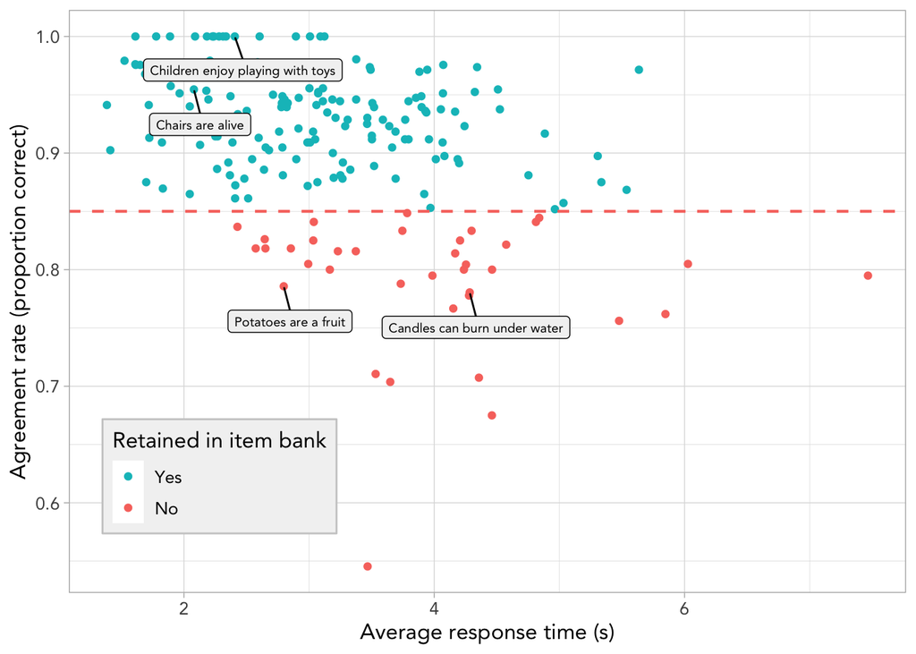

```r
#ggplotly(filtered.plot)
filtered.plot
```

Figure 2: Inspecting relationship between agreement rate and average RT

```r
df.quad.plot <- df.lab.items.filtered.v2

quad.plot <- ggplot(data = df.quad.plot, label = sentence, aes(label = sentence)) +
  geom_point(data = df.quad.plot, mapping = aes(x = avgRTStd,
                     y = pCorrStd, color=numCharacter)) +
  labs(color = "Sentence length \n(Number of \ncharacters)") +
  geom_label_repel(data = df.quad.plot %>%
                     filter(sentenceId == "lab_56"),
                   aes(avgRTStd, pCorrStd, label=sentence),
                   nudge_x = 0.3, nudge_y = -0.5,
                   fill = "gray95", family="Avenir", size = 2.5) +
  scale_x_continuous(limits = c(-2.5, 2.5), breaks = round(seq(-2.5, 2.5)), "Standardized average response time (s)") +
  scale_y_continuous(limits = c(-2, 2), breaks = round(seq(-2, 2)),"Standardized average agreement rate") +
  scale_color_viridis(option = 'viridis') +
  theme_light() +
  theme(text=element_text(family="Avenir", size=12),
        axis.title = element_text(face = "bold"),
        legend.position = c(0.25, 0.15),
        legend.direction = "horizontal",
        legend.background = element_rect(fill="gray95", linewidth = 0.5, linetype ="solid", colour ="gray80"))
```

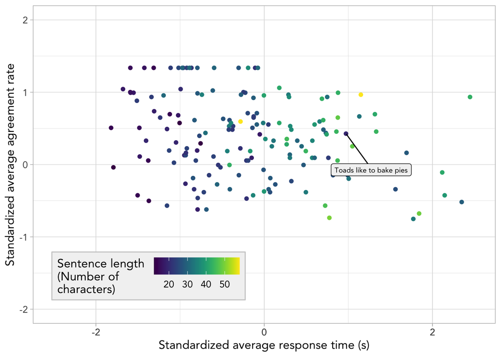

```r
#ggplotly(quad.plot)
quad.plot
```

### 3.2.1 Removing a sentence because of the long response time despite the short character length

```r
df.lab.items.filtered.v3 <- df.lab.items.filtered.v2 %>%
  filter(sentenceId != "lab_56")
```

Figure 3: Scatter plot of SRE-Pilot vs. SRE-Fixed vs. TOSREC

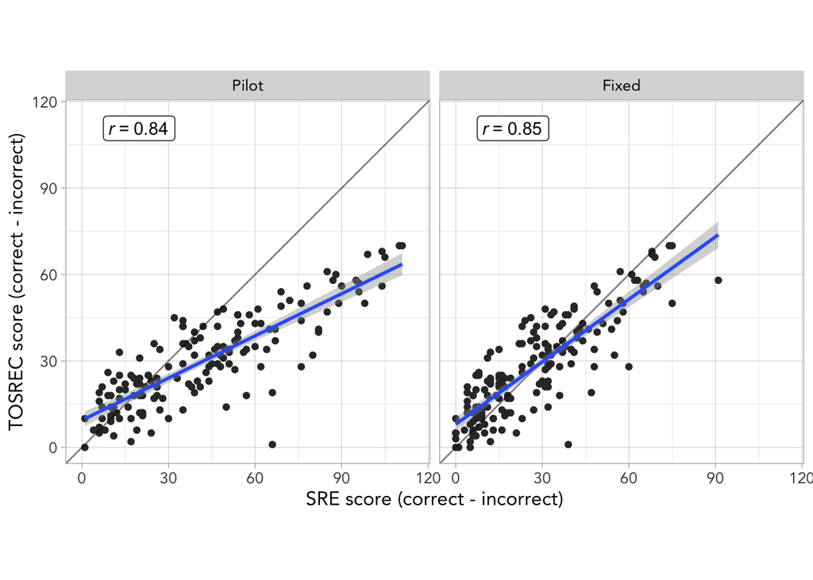

```r
df.scatter.plot <- df.sre.tosrec.scores

pilot.fixed.scatter <- ggplot(df.scatter.plot, mapping = aes(x = labFinalScore, y = tosrecFinalScore)) +
  geom_point(size = 1.5, color = "gray20") +
  geom_abline(slope=1,intercept = 0, size=0.5, alpha = 0.5) +
  geom_smooth(method = "lm") +
  facet_wrap(~~fct_rev(labCorpus)) +
  stat_cor(cor.coef.name = 'r', aes(label = ..r.label..), color = "black",
           geom = "label", hjust = -0.3, vjust = 1) +
  scale_x_continuous(limits = c(0, 115)) +
  scale_y_continuous(limits = c(0, 115)) +
  labs(x = "SRE score (correct - incorrect)",
       y = "TOSREC score (correct - incorrect)",
       color = "SRE Form") +
  theme_light() +
  theme(text=element_text(family="Avenir", size=12),
        axis.title = element_text(face = "bold"),
        strip.text = element_text(colour = 'black'),
        strip.background = element_rect(fill="gray85"),
        aspect.ratio = 1)
pilot.fixed.scatter
```

### 3.2.2 Matching items based on easy, medium, and hard difficulty

In order to ensure that we have an equal number of true and false sentences, we used the R package [MatchIt](https://cran.r-project.org/web/packages/MatchIt/vignettes/MatchIt.html) to match the items based on item difficulty (or proportion correct). Note that difficulties for each item were defined as:

- **Easy**: Items that have a proportion correct greater than 0.95
- **Medium**: Items that have a proportion correct greater than 0.90 but less than or equal to 0.95
- **Hard**: Items that have a proportion correct less than than 0.90

### 3.2.3 Matching easy sentences

After matching the easy sentences, 40 sentences (20 true and 20 false) were included in the final set of sentences.

#### 3.2.3.1 Excluded easy sentences

```r
df.easy.excluded
```

```
   sentenceId                                                  sentence
1      lab_46                               Knives are used for cutting
2      lab_54                               Some kids have blue crayons
3      lab_79                              Chocolate is a type of candy
4      lab_83                            Some people keep birds as pets
5      lab_84                    Some people eat pancakes for breakfast
6     lab_135                    Breakfast is the first meal of the day
7     lab_138                   Some people get to work using the train
8     lab_158       Many people like wearing shoes when they go outside
9     lab_171 When it is raining outside, many fields will become muddy
10    lab_181        Some kids want to become writers when they grow up
   answerKey itemNum attempted correct     pCorr  pCorrStd       sum    avgRT
1       TRUE      46        31      30 0.9677419 0.8820929  52.38303 1.689775
2       TRUE      54        42      40 0.9523810 0.6655083 129.07389 3.073188
3       TRUE      79        35      34 0.9714286 0.9340733  63.32416 1.862475
```

[output cut: 18 more lines]

#### 3.2.3.2 Final easy sentences

```r
df.lab.items.easy.final
```

```
   sentenceId
1       lab_0
2       lab_1
3       lab_4
4       lab_6
5       lab_8
6      lab_12
7      lab_16
8      lab_25
9      lab_32
10     lab_33
11     lab_35
12     lab_40
13     lab_44
16     lab_55
```

[output cut: 149 more lines]

### 3.2.4 Matching medium sentences

```r
df.lab.items.medium <- df.lab.items.filtered.difficulty %>%
  filter(difficulty == "Medium")
```

After matching the medium sentences, 64 sentences (32 true and 32 false) were included in the final set of sentences.

#### 3.2.4.1 Excluded medium sentences

```r
df.medium.excluded
```

```
  sentenceId
1      lab_2
2     lab_62
3     lab_72
4    lab_103
5    lab_109
6    lab_132
7    lab_137
8    lab_175
9    lab_197
                                                                sentence
1                                                         Cats can drink
2                                       Squirrels will climb trees often
3                                           A baker works in the kitchen
4                                        People can buy chairs in stores
```

[output cut: 25 more lines]

#### 3.2.4.2 Final medium sentences

```r
df.lab.items.medium.final
```

```
   sentenceId                                                  sentence
2       lab_3                                            Bears can talk
3       lab_7                                            Mice have ears
4      lab_10                                         The sun is bright
5      lab_11                                      Whales have two legs
6      lab_13                                    All flowers are yellow
7      lab_14                               People sometimes drink milk
8      lab_15                                        Cows sing at night
9      lab_18                               Elephants are large animals
10     lab_21                                      Apples grow on trees
11     lab_22                                    Kittens are young cats
12     lab_27                                     Some shoes have laces
13     lab_28                                         Adults can be sad
14     lab_30                                     Moms like eating hats
15     lab_31                                    Many babies drink milk
```

[output cut: 180 more lines]

### 3.2.5 Matching hard sentences

After matching the hard sentences, 26 sentences (13 true and 13 false) were included in the final set of sentences.

#### 3.2.5.1 Excluded hard sentences

```r
df.hard.excluded
```

```
  sentenceId                                                sentence answerKey
1     lab_20                                Fire gives you frostbite     FALSE
2     lab_26                                  All girls wear dresses     FALSE
3     lab_59                         Camels enjoy wearing flip-flops     FALSE
4     lab_67                           Stones are kept in the fridge     FALSE
5     lab_97                          Every fish lives in a fishbowl     FALSE
6    lab_108                       The sun is smaller than the Earth     FALSE
7    lab_125                      Every door is a sliding glass door     FALSE
8    lab_130                Leaves on trees turn green when they die     FALSE
9    lab_173 Most adults walk with their hands instead of their feet     FALSE
  itemNum attempted correct     pCorr   pCorrStd       sum    avgRT    avgRTStd
1      20        42      37 0.8809524 -0.3416102  94.69809 2.367452 -0.83339861
2      26        44      39 0.8863636 -0.2653134  99.65924 2.264983 -0.93624256
3      59        36      31 0.8611111 -0.6213654  85.44953 2.513221 -0.68709690
4      67        37      32 0.8648649 -0.5684387  71.62725 2.046493 -1.15553045
5      97        36      32 0.8888889 -0.2297082 126.69766 3.519379  0.32273649
6     108        37      33 0.8918919 -0.1873669  82.42029 2.354865 -0.84603155
7     125        37      33 0.8918919 -0.1873669 117.72194 3.270054  0.07250017
8     130        46      41 0.8913043 -0.1956510 188.94052 4.198678  1.00451670
9     173        37      32 0.8648649 -0.5684387 141.11462 3.919851  0.72467064
  numWords numCharacter difficulty
1        4           21       Hard
2        4           19       Hard
3        5           28       Hard
4        6           24       Hard
5        6           25       Hard
6        7           27       Hard
7        7           28       Hard
8        8           33       Hard
9       10           46       Hard
```

#### 3.2.5.2 Final hard sentences

```r
df.lab.items.hard.final
```

```
   sentenceId                                                     sentence
1       lab_9                                             Wheels are round
2      lab_17                                        Doors are always open
5      lab_34                                            A raven is a bird
6      lab_41                               Dish washers make plates dirty
7      lab_48                                    A tricycle has two wheels
8      lab_52                           Trampolines help you bounce higher
10     lab_68                                 A cactus grows under the sea
11     lab_76                              There are many types of lizards
12     lab_80                      Television shows are longer than movies
13     lab_86                                Ice helps to keep things cold
14     lab_92                                 A gardener works at a bakery
15     lab_96                              Snow always falls in the summer
17    lab_102                           Halloween is a holiday in February
19    lab_111                             A mouse is a rodent that squeaks
```

[output cut: 66 more lines]

### 3.2.6 Final set of sentences

We are left with a final stimuli bank of 130 sentences, consisting of 40 easy, 64 medium, and 26 hard sentences.

```r
df.lab.items.final <- df.lab.items.easy.final %>%
  rbind(df.lab.items.medium.final) %>%
  rbind(df.lab.items.hard.final)
```

```r
df.lab.items.final
```

```
    sentenceId
1        lab_0
2        lab_1
3        lab_4
4        lab_6
5        lab_8
6       lab_12
7       lab_16
8       lab_25
9       lab_32
10      lab_33
11      lab_35
12      lab_40
13      lab_44
16      lab_55
```

[output cut: 640 more lines]

## 3.3 Final order of sentences (130 sentences in fixed order)

```r
set.seed(20)
```

```r
easy.length <- sample(nrow(df.lab.items.easy.final))
easy.final <- df.lab.items.easy.final[easy.length,] %>%
  mutate(difficulty = "Easy")
```

```r
medium.length <- sample(nrow(df.lab.items.medium.final))
medium.final <- df.lab.items.medium.final[medium.length,] %>%
  mutate(difficulty = "Medium")
```

```r
hard.length <- sample(nrow(df.lab.items.hard.final))
hard.final <- df.lab.items.hard.final[hard.length,] %>%
  mutate(difficulty = "Hard")
```

# 4 Run this chunk to save the plots

```r
ggsave('figures/SRE-Pilot-PCorr-RT-Scatter.png', filtered.plot, height = 4, width = 7, dpi=300)
ggsave('figures/SRE-Pilot-Quad-Scatter.png', quad.plot, height = 4, width = 7, dpi=300)
ggsave('figures/SRE-Fixed-Pilot-Scatter.png', pilot.fixed.scatter, height = 7, width = 7, dpi=300)
```